# More on Tibbles

Andy Wills

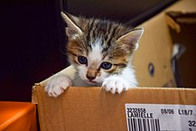

Kitten that might be called Tibbles. Possibly.

In the Exploring Data worksheet, you got the mean income of your sample like this:

```r
cpsdata %>% summarise(mean(income))
```

```
# A tibble: 1 x 1
  `mean(income)`
           <dbl>
1         87293.
```

The answer is the last number on the bottom right – but what about all that other stuff in the output? What the hell is a tibble? You can safely ignore the extra stuff but, if you’re curious, here’s what it all means…

1. The first line, `A tibble: 1 x 1`, says your output is a data frame (aka. `tibble`) with one row and one column … so, a single number. No, I don’t think anyone knows why it’s called a tibble.
2. The second line tells you what summary you calculated – `mean(income)`, the mean of the incomes.
3. The third line, `<dbl>` tells you that what you calculated is a number (in case you were wondering `dbl` is short for ‘double precision floating point number’, but that’s probably more detail than you needed…).
4. The fourth line gives you the number you calculated, the mean income of `87293`. The `1` at the beginning is a row number, which you can ignore.

If you look at the number `87293.` really closely in your output, you’ll notice two more things about it:

1. The first two numbers, `87` are underlined, while the others are not. This is just a way of making big numbers easier to read, much like writing 87,293 rather than 87293. This underlining shows up in your R Console window, but not on these worksheets – sorry about that!
2. There’s a decimal point at the end, but no numbers following the decimal point. This lets you know that the answer has been rounded to the nearest whole number. You’ll always get an answer that is correct to at least three significant figures, which is generally enough for reporting your findings. There are ways to get a more precise output if you need it, but we don’t cover those in this class.

```r
cpsdata %>% group_by(sex) %>% summarise(median(income))
```

```
# A tibble: 2 x 2
  sex    `median(income)`
  <chr>             <dbl>
1 female           52558.
2 male             61746.
```

This can be read much the same way as the last example. These are the differences:

- Your tibble is now 2 x 2 because it has two rows (female, male) and two columns (sex, median income).
- The `<chr>` in sex column says that column contains letters (male, female) rather than numbers – chr is short for “characters” (another word for letters).

This material is distributed under a [Creative Commons](https://creativecommons.org/) licence. CC-BY-SA 4.0.

Kitten picture by 0x010C - Own work, CC BY-SA 4.0, https://commons.wikimedia.org/w/index.php?curid=42929793